# Report 1: Shared plant knowledge

```r
##Init
library("readxl")
library("lessR")
library("lme4")
try(setwd(dirname(rstudioapi::getActiveDocumentContext()$path)), silent = TRUE)
#not necessary in VSCode, just let it error out there

##Data Ingest
m_participants <- read_excel("plant_participants.xlsx")
m_plants <- read_excel("plant_knowledge.xlsx")

##Data Prep
m_participants <- subset(m_participants, select = -c(6))
nrow(m_participants) == length(unique(m_participants$id))
```

```
## [1] TRUE
```

```r
#True means no repetitions in id
for(i in 1 : ncol(m_participants)){
  m_participants <- m_participants[m_participants[, i] != "NA",]
}
m_plants <- m_plants[m_plants$id %in% m_participants$id,]
#I know you said not to remove individuals with NAs, but they were causing problems later, so this step made sense to me.
m_participants$age <- ifelse(m_participants$age == "5-10", "05-10", m_participants$age)
```

1. **Plant knowledge file**
1. After removing plants with NAs, how many plants are left in the dataset?

```r
m_plants <- subset(m_plants, select = -c(6, 18, 26, 28))
nplants <- ncol(m_plants) - 1 #-1 is the ID column
nplants
```

```
## [1] 31
```

2. Calculate the total sum of knowledge by plant (how many people know each plant). Are some plants more popular than others? What is the average by plant? Plot a histogram with the distribution.

```r
plantcolsums <- colSums((subset(m_plants, select = -c(1))))
mean(plantcolsums)
```

```
## [1] 147.9355
```

```
## >>> Note: plantcolsums is from the workspace, not in a data frame (table)
```

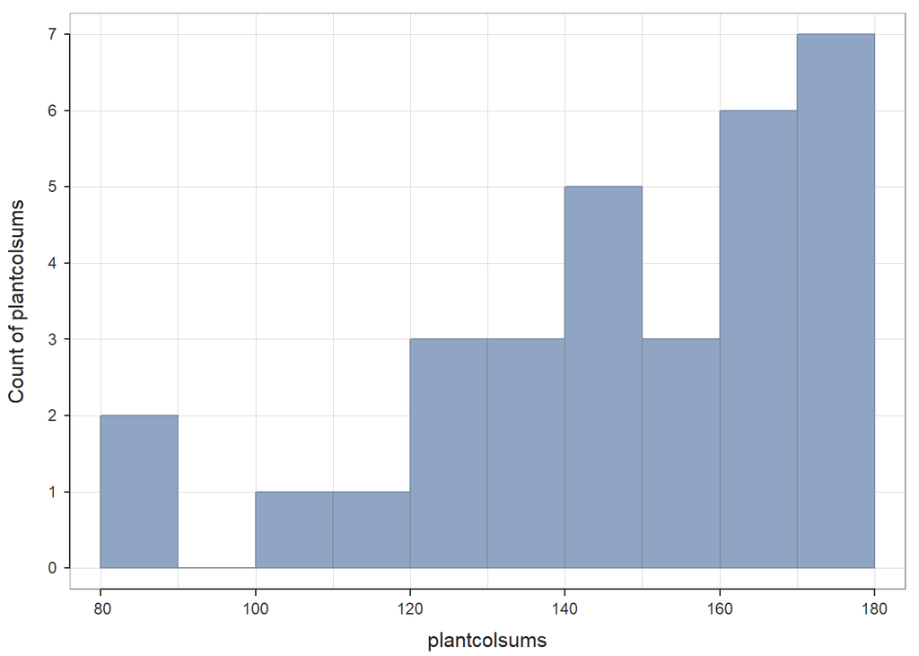

```
## >>> Suggestions
## bin_start: set the start of the first bin
## bin_end: set the end of the last bin
## Density(plantcolsums)  # smoothed density curves plus histogram
## Plot(plantcolsums)  # Violin/Box/Scatterplot (VBS) plot
##
##
## --- plantcolsums ---
##
##      n   miss      mean        sd       min       mdn       max
##      31      0    147.94     25.38     82.00    153.00    177.00
##
##
## (Box plot) Outliers: 1
##
## Small       Large
## -----       -----
##  82.0
##
##
## Bin Width: 10
## Number of Bins: 10
##
##        Bin  Midpnt  Count    Prop  Cumul.c  Cumul.p
## ---------------------------------------------------
##   80 >  90      85      2    0.06        2     0.06
##   90 > 100      95      0    0.00        2     0.06
##  100 > 110     105      1    0.03        3     0.10
##  110 > 120     115      1    0.03        4     0.13
##  120 > 130     125      3    0.10        7     0.23
##  130 > 140     135      3    0.10       10     0.32
##  140 > 150     145      5    0.16       15     0.48
##  150 > 160     155      3    0.10       18     0.58
##  160 > 170     165      6    0.19       24     0.77
##  170 > 180     175      7    0.23       31     1.00
```

```r
Histogram(plantcolsums, bin_width = 10)
```

There is variation in plant knowledge by plant, though most plants seem to be known by many people, with only four plants known by less than 120 people (out of 179 people and 31 plants). A plant is known by 147.9 people on average.

3. Calculate total knowledge by individual. Is plant knowledge variable among individuals? What is the average plant knowledge by individual? Plot a histogram.

```r
plantrowsums <- rowSums((subset(m_plants, select = -c(1))))
mean(plantrowsums)
```

```
## [1] 25.62011
```

```
## >>> Note: plantrowsums is from the workspace, not in a data frame (table)
```

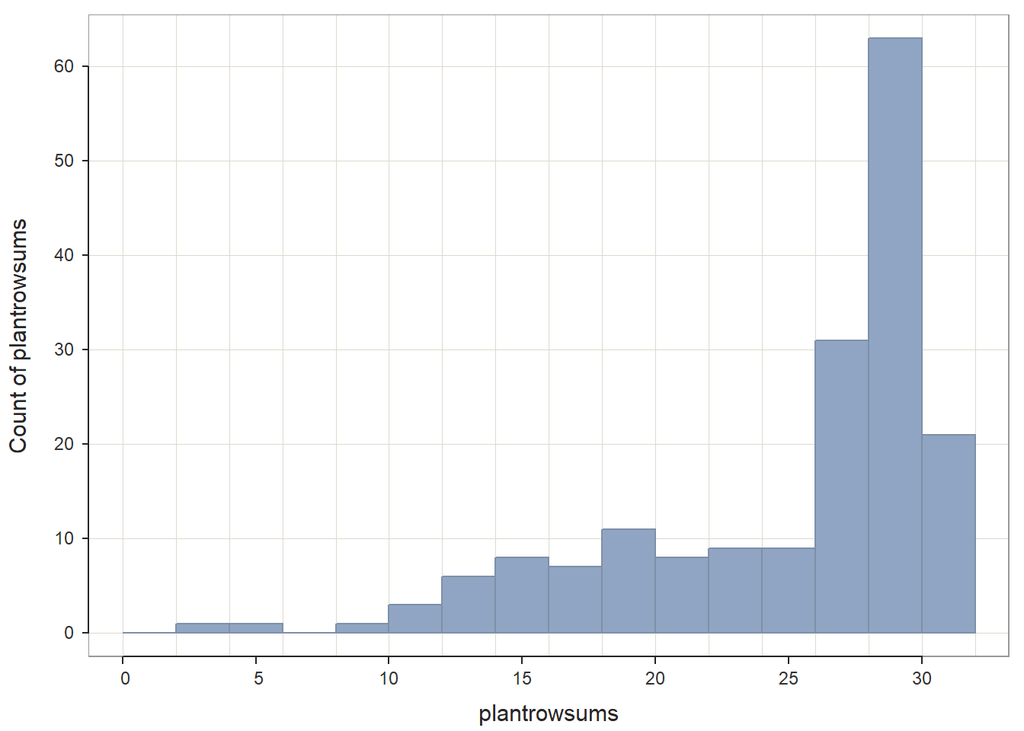

```
## >>> Suggestions
## bin_start: set the start of the first bin
## Density(plantrowsums)  # smoothed density curves plus histogram
## Plot(plantrowsums)  # Violin/Box/Scatterplot (VBS) plot
##
##
## --- plantrowsums ---
##
##       n   miss     mean       sd      min      mdn      max
##      179      0    25.62     5.88     4.00    28.00    31.00
##
##
## (Box plot) Outliers: 2
##
## Small      Large
## -----      -----
##  4.0
##  6.0
##
##
## Bin Width: 2
## Number of Bins: 16
##
##      Bin  Midpnt  Count    Prop  Cumul.c  Cumul.p
## -------------------------------------------------
##   0 >  2       1      0    0.00        0     0.00
##   2 >  4       3      1    0.01        1     0.01
##   4 >  6       5      1    0.01        2     0.01
##   6 >  8       7      0    0.00        2     0.01
##   8 > 10       9      1    0.01        3     0.02
##  10 > 12      11      3    0.02        6     0.03
##  12 > 14      13      6    0.03       12     0.07
##  14 > 16      15      8    0.04       20     0.11
##  16 > 18      17      7    0.04       27     0.15
##  18 > 20      19     11    0.06       38     0.21
##  20 > 22      21      8    0.04       46     0.26
##  22 > 24      23      9    0.05       55     0.31
##  24 > 26      25      9    0.05       64     0.36
##  26 > 28      27     31    0.17       95     0.53
##  28 > 30      29     63    0.35      158     0.88
##  30 > 32      31     21    0.12      179     1.00
```

```r
Histogram(plantrowsums, bin_width = 2, bin_end = 31)
```

Again there is variation, though there is a sharp peak in the histogram shortly before 30 plants known per person, with most people falling in the range from 27 to 30. Not surprisingly, the average of 25.6 plants known per person is very close to that range, being pulled to the bottom of it only by the fact that there are more exceptionally “ignorant” (might just be young or other reasons) than exceptionally knowledgeable individuals.

2. **Plant participants file**
1. What is the age distribution in the sample? Produce a table.

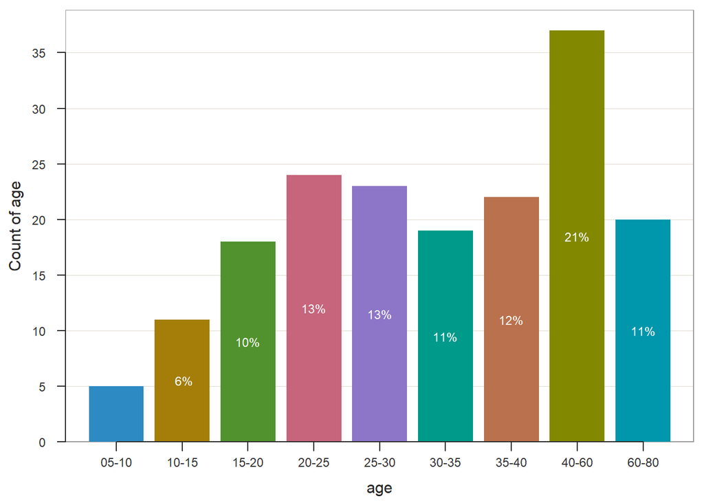

```
## >>> Suggestions
## BarChart(age, horiz=TRUE)  # horizontal bar chart
## BarChart(age, fill="greens")  # sequential green bars
## PieChart(age)  # doughnut (ring) chart
## Plot(age)  # bubble plot
## Plot(age, stat="count")  # lollipop plot
##
##
## --- age ---
##
##
## Missing Values of age: 0
##
##
##   age Count   Prop
## -------------------
## 05-10     5   0.028
## 10-15    11   0.061
## 15-20    18   0.101
## 20-25    24   0.134
## 25-30    23   0.128
## 30-35    19   0.106
## 35-40    22   0.123
## 40-60    37   0.207
## 60-80    20   0.112
## -------------------
## Total   179   1.000
##
##
## Chi-squared test of null hypothesis of equal probabilities
##   Chisq = 31.620, df = 8, p-value = 0.000
```

```r
BarChart(age, data = m_participants)
```

2. Which fraction is pre-adult (5-10 or 10-15 years old)?

```r
nrow(m_participants[m_participants$age == "05-10" | m_participants$age == "10-15",]) /
  nrow(m_participants)
```

```
## [1] 0.08938547
```

3. What is the sex ratio in the sample?

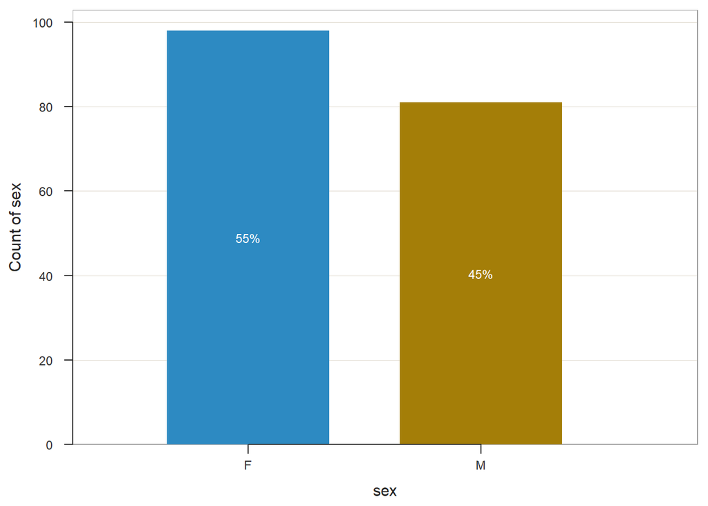

```
## >>> Suggestions
## BarChart(sex, horiz=TRUE)  # horizontal bar chart
## BarChart(sex, fill="greens")  # sequential green bars
## PieChart(sex)  # doughnut (ring) chart
## Plot(sex)  # bubble plot
## Plot(sex, stat="count")  # lollipop plot
##
##
## --- sex ---
##
##
## Missing Values of sex: 0
##
##
##                    F      M     Total
## Frequencies:      98     81       179
## Proportions:   0.547  0.453     1.000
##
##
## Chi-squared test of null hypothesis of equal probabilities
##   Chisq = 1.615, df = 1, p-value = 0.204
```

```r
BarChart(sex, data = m_participants)
```

3. **Dyads**

```r
m_dyads <- data.frame(t(combn(m_participants$id, 2)))
colnames(m_dyads) <- c("id1", "id2")
m_dyads <- merge(m_dyads, m_participants, by.x = "id1", by.y = "id")
colnames(m_dyads)[c(3, 4, 5, 6, 7)] <-
    c("camp1", "sex1", "age1", "born1", "learned1")
m_dyads <- merge(m_dyads, m_participants, by.x = "id2", by.y = "id")
m_dyads <- m_dyads[, c(2, 1, 3, 4, 5, 6, 7, 8, 9, 10, 11, 12)]
m_dyads <- m_dyads[order(m_dyads$id1), ]
colnames(m_dyads)[c(8, 9, 10, 11, 12)] <-
    c("camp2", "sex2", "age2", "born2", "learned2")
m_dyads$dyadid <- paste(m_dyads$id1, m_dyads$id2, sep = "_")
```

1. How many dyads are FF, MM, and FM?

```r
m_dyads$dyadsex <- paste0(pmin(m_dyads$sex1, m_dyads$sex2),
                          pmax(m_dyads$sex1, m_dyads$sex2))
table(m_dyads$dyadsex)
```

```
##
##   FF   FM   MM
## 4753 7938 3240
```

```r
m_dyads$dyadsamesex <- ifelse(m_dyads$dyadsex == "mm" |
                        m_dyads$dyadsex == "ff", 1, 0)
```

2. How many dyads are ‘young’ (both individuals are 15 or under) and old (both over 60)?

```r
m_dyads$dyadage <- paste(pmin(m_dyads$age1, m_dyads$age2),
                         pmax(m_dyads$age1, m_dyads$age2),
                         sep = "_")
m_dyads$dyadagegroup <- ifelse(m_dyads$dyadage == "05-10_05-10" |
                              m_dyads$dyadage == "05-10_10-15" |
                              m_dyads$dyadage == "10-15_10-15", "young", "other")
m_dyads$dyadagegroup <- ifelse(m_dyads$dyadage == "60-80_60-80", "old", m_dyads$dyadagegroup)
table(m_dyads$dyadagegroup)
```

```
##
##   old other young
##   190 15621   120
```

3. How many dyads born in same vs. different camp? (use born instead of born_cluster)

```r
m_dyads$dyadborn <- paste(pmin(m_dyads$born1, m_dyads$born2),
                          pmax(m_dyads$born1, m_dyads$born2),
                          sep = "_")
m_dyads$dyadsameborn <- ifelse(m_dyads$born1 == m_dyads$born2, 1, 0)
table(m_dyads$dyadsameborn)
```

```
##
##     0     1
## 12872  3059
```

3059 were born in the same camp vs 12872 who were born in different camps.

4. How many subjects were in the same vs. different camps during the interviews?

```r
m_dyads$dyadcamp <- paste(pmin(m_dyads$camp1, m_dyads$camp2),
                          pmax(m_dyads$camp1, m_dyads$camp2),
                          sep = "_")
m_dyads$dyadsamecamp <- ifelse(m_dyads$camp1 == m_dyads$camp2, 1, 0)
table(m_dyads$dyadsamecamp)
```

```
##
##     0     1
## 11660  4271
```

4271 were interviewed in the same camp vs 11660 who were interviewed in different camps.

```r
m_dyadsknowledge <- m_dyads
nplants <- ncol(m_plants) - 1
nindiv <- nrow(m_plants)
ndyads <- nrow(m_dyads)

#replicate lines to match number of shared traits per dyad (=plant number)
m_dyadsknowledge <- m_dyadsknowledge[rep(1:ndyads, each = nplants), ]

#create plant knowledge column in m_dyadsknowledge file
#repeat=  number of_plants; times = nymber of_dyads
m_dyadsknowledge$plant <- rep(1:nplants, times = ndyads)

#create a file with plant knowledge and shared plant knowledge
#make a file with id and plant
m_plants2 <- m_plants[rep(1:nindiv, each = nplants), ]
#but only want the id column
m_plants2 <- subset(m_plants2, select = id)
#change it to id1
colnames(m_plants2)[1] <- "id1"
#add plant column
m_plants2$plant <- rep(1:nplants, times = nindiv)

#create a plant knowledge column
#transpose whole m.plant file into single column of plant knowledge
#but first exclude the columns that are not about plant knowledge
m_plants3 <- subset(m_plants, select = -c(id))
m_plants2$know <- c(t(m_plants3))

#merge_dyads and plant file
#first include id1 knowledge
m_dyadsknowledge <- merge(m_dyadsknowledge, m_plants2, by = c("id1", "plant"))
#reorder by id
m_dyadsknowledge <- m_dyadsknowledge[order(m_dyadsknowledge$id1, m_dyadsknowledge$id2), ]
#id1 knowledge: change name from know to know1
index <- grep("^know$", colnames(m_dyadsknowledge))
colnames(m_dyadsknowledge)[index] <- "know1"

#then id2 knowledge
#change column names to allow proper matching
colnames(m_plants2)[1] <- "id2"
colnames(m_plants2)[3] <- "know2"
m_dyadsknowledge <- merge(m_dyadsknowledge, m_plants2, by = c("id2", "plant"))

#reorder columns and rows (I attempted to make this robust to changes I make avobe)
index <- grep("^dyadid$", colnames(m_dyadsknowledge))
cols <- ncol(m_dyadsknowledge)
m_dyadsknowledge <- m_dyadsknowledge[c(3, 1, index, 4:(index - 1),
    (index + 1):(cols - 2), 2, cols - 1, cols)]
m_dyadsknowledge <- m_dyadsknowledge[order(m_dyadsknowledge$id1, m_dyadsknowledge$id2), ]
m_dyadsknowledge$shared <- ifelse(m_dyadsknowledge$know1 == 1 & m_dyadsknowledge$know2 == 1, 1, 0)

index <- grep("^dyadid$", colnames(m_dyads))
cols <- ncol(m_dyads)
m_dyads <- m_dyads[c(1, 2, index, 3:(index - 1),
    (index + 1):cols)]
m_dyads <- m_dyads[order(m_dyads$id1, m_dyads$id2), ]

#factorize
for(i in c(1:14, 16:18, 20)){
  m_dyads[, i] <- as.factor(m_dyads[, i])
  m_dyadsknowledge[, i] <- as.factor(m_dyadsknowledge[, i])
}
#releveling
m_dyads$dyadagegroup <- relevel(m_dyads$dyadagegroup, ref = "other")
m_dyads$dyadsex <- relevel(m_dyads$dyadsex, ref = "FM")
m_dyadsknowledge$dyadagegroup <- relevel(m_dyadsknowledge$dyadagegroup, ref = "other")
m_dyadsknowledge$dyadsex <- relevel(m_dyadsknowledge$dyadsex, ref = "FM")
```

4. Total score Assuming (incorrectly) that the data points are independent, we can define ‘total score’ (between 0 and 31) as the sum of shared knowledge by each dyad. Is there a difference in total score as a function of dyadic:

```r
temp <- vector()
for(id in m_dyads$dyadid){
  temp <- append(temp, sum(m_dyadsknowledge[m_dyadsknowledge$dyadid == id, 25]))
}
m_dyads$totalscore <- temp
```

1. Age? (define it as young, old, or others)

```r
lm_1age <- lm(totalscore ~ dyadagegroup, data = m_dyads)
summary(lm_1age)
```

```
##
## Call:
## lm(formula = totalscore ~ dyadagegroup, data = m_dyads)
##
## Residuals:
##     Min      1Q  Median      3Q     Max
## -20.749  -4.749   1.251   6.251  13.300
##
## Coefficients:
##                    Estimate Std. Error t value            Pr(>|t|)
## (Intercept)        21.74944    0.05198  418.44 <0.0000000000000002
## dyadagegroupold     6.84003    0.47416   14.43 <0.0000000000000002
## dyadagegroupyoung -10.04944    0.59531  -16.88 <0.0000000000000002
##
## Residual standard error: 6.496 on 15928 degrees of freedom
## Multiple R-squared:  0.0303, Adjusted R-squared:  0.03018
## F-statistic: 248.9 on 2 and 15928 DF,  p-value: < 0.00000000000000022
```

This indicates that dyads where both people are old tend to share more knowledge about plants, whereas dyads with two young members share less knowledge, both in comparison to all other dyads. Both of these effects are significant.

2. Sex? (MM, MF, FF)

```r
lm_1sex <- lm(totalscore ~ dyadsex, data = m_dyads)
summary(lm_1sex)
```

```
##
## Call:
## lm(formula = totalscore ~ dyadsex, data = m_dyads)
##
## Residuals:
##     Min      1Q  Median      3Q     Max
## -20.865  -4.966   1.135   5.135  11.034
##
## Coefficients:
##             Estimate Std. Error t value            Pr(>|t|)
## (Intercept) 21.86521    0.07225  302.65 <0.0000000000000002
## dyadsexFF   -1.89929    0.11805  -16.09 <0.0000000000000002
## dyadsexMM    2.24591    0.13419   16.74 <0.0000000000000002
##
## Residual standard error: 6.437 on 15928 degrees of freedom
## Multiple R-squared:  0.04803,    Adjusted R-squared:  0.04791
## F-statistic: 401.8 on 2 and 15928 DF,  p-value: < 0.00000000000000022
```

This indicates that dyads with two males share more knowledge and dyads with two females share less, both in comparison to mixed sex dyads. Both of these effects are quite weak, but significant.

3. Camp? (define it as same vs different camp)

```r
lm_1camp <- lm(totalscore ~ dyadsamecamp, data = m_dyads)
summary(lm_1camp)
```

```
##
## Call:
## lm(formula = totalscore ~ dyadsamecamp, data = m_dyads)
##
## Residuals:
##     Min      1Q  Median      3Q     Max
## -20.876  -4.876   1.124   6.124   9.575
##
## Coefficients:
##              Estimate Std. Error t value             Pr(>|t|)
## (Intercept)  21.87642    0.06107  358.25 < 0.0000000000000002
## dyadsamecamp -0.45169    0.11794   -3.83             0.000129
##
## Residual standard error: 6.594 on 15929 degrees of freedom
## Multiple R-squared:  0.00092,    Adjusted R-squared:  0.0008573
## F-statistic: 14.67 on 1 and 15929 DF,  p-value: 0.0001287
```

This indicates that dyads where both members were interviewed at the same camp share less knowledge than those interviewed at different camps. This very weak effect is significant (though less so than previous effects). Interesting here is that I would have expected the opposite effect.

4. Birthplace? (same or different) Under that wrong assumption, which tests would you select? Why? Run this test for dyadic sex.

```r
lm_1born <- lm(totalscore ~ dyadsameborn, data = m_dyads)
summary(lm_1born)
```

```
##
## Call:
## lm(formula = totalscore ~ dyadsameborn, data = m_dyads)
##
## Residuals:
##     Min      1Q  Median      3Q     Max
## -20.838  -4.838   1.162   6.162   9.592
##
## Coefficients:
##              Estimate Std. Error t value             Pr(>|t|)
## (Intercept)  21.83779    0.05813 375.691 < 0.0000000000000002
## dyadsameborn -0.42948    0.13265  -3.238              0.00121
##
## Residual standard error: 6.595 on 15929 degrees of freedom
## Multiple R-squared:  0.0006577,  Adjusted R-squared:  0.0005949
## F-statistic: 10.48 on 1 and 15929 DF,  p-value: 0.001207
```

This indicates that dyads whose members were born in the same camp share less knowledge than those born in different camps. Just like above, this effect is very weak, and though significant, less so than other effects. And once again, I am surprised by the effect going the opposite way from what I expected.

I don’t know what test to use.. I would just compare my models using the R-squared values. Sex is the best one of the models above according to that.

5. Regression analysis Run a logistic analysis (i.e. not controlling for pseudoreplication) to predict shared knowledge as a function of dyadic:
1. Age

```r
lm_2age <- glm(shared ~ dyadagegroup, data = m_dyadsknowledge, family = binomial)
summary(lm_2age)
```

```
##
## Call:
## glm(formula = shared ~ dyadagegroup, family = binomial, data = m_dyadsknowledge)
##
## Deviance Residuals:
##     Min       1Q   Median       3Q      Max
## -2.2601  -1.5552   0.8419   0.8419   1.3960
##
## Coefficients:
##                    Estimate Std. Error z value            Pr(>|z|)
## (Intercept)        0.854904   0.003141  272.21 <0.0000000000000002
## dyadagegroupold    1.618288   0.048725   33.21 <0.0000000000000002
## dyadagegroupyoung -1.355420   0.033969  -39.90 <0.0000000000000002
##
## (Dispersion parameter for binomial family taken to be 1)
##
##     Null deviance: 601863  on 493860  degrees of freedom
## Residual deviance: 598459  on 493858  degrees of freedom
## AIC: 598465
##
## Number of Fisher Scoring iterations: 4
```

This indicates that dyads where both members are old are more likely to share knowledge about a plant, and dyads with two young members are less likely to share that knowledge, both in comparison to all other dyads.

2. Sex

```r
lm_2sex <- glm(shared ~ dyadsex, data = m_dyadsknowledge, family = binomial)
summary(lm_2sex)
```

```
##
## Call:
## glm(formula = shared ~ dyadsex, family = binomial, data = m_dyadsknowledge)
##
## Deviance Residuals:
##     Min       1Q   Median       3Q      Max
## -1.7344  -1.4374   0.8356   0.8356   0.9380
##
## Coefficients:
##              Estimate Std. Error z value            Pr(>|z|)
## (Intercept)  0.872806   0.004422  197.39 <0.0000000000000002
## dyadsexFF   -0.279768   0.007011  -39.90 <0.0000000000000002
## dyadsexMM    0.379957   0.008784   43.26 <0.0000000000000002
##
## (Dispersion parameter for binomial family taken to be 1)
##
##     Null deviance: 601863  on 493860  degrees of freedom
## Residual deviance: 596646  on 493858  degrees of freedom
## AIC: 596652
##
## Number of Fisher Scoring iterations: 4
```

This indicates that dyads with two males are more likely to share knowledge and dyads with two females are less likely to share it, both in comparison to mixed sex dyads.

3. Camp

```r
lm_2camp <- glm(shared ~ dyadsamecamp, data = m_dyadsknowledge, family = binomial)
summary(lm_2camp)
```

```
##
## Call:
## glm(formula = shared ~ dyadsamecamp, family = binomial, data = m_dyadsknowledge)
##
## Deviance Residuals:
##     Min       1Q   Median       3Q      Max
## -1.5640  -1.5328   0.8350   0.8350   0.8596
##
## Coefficients:
##               Estimate Std. Error z value            Pr(>|z|)
## (Intercept)   0.874546   0.003650 239.620 <0.0000000000000002
## dyadsamecamp -0.069185   0.006979  -9.914 <0.0000000000000002
##
## (Dispersion parameter for binomial family taken to be 1)
##
##     Null deviance: 601863  on 493860  degrees of freedom
## Residual deviance: 601765  on 493859  degrees of freedom
## AIC: 601769
##
## Number of Fisher Scoring iterations: 4
```

This indicates that dyads where both members were interviewed at the same camp are less likely to share knowledge than those interviewed at different camps. Just like in the first set of models, the effect goes the opposite way from what I expected but is significant, though once again less so than age and sex.

4. Birthplace

```r
lm_2born <- glm(shared ~ dyadsameborn, data = m_dyadsknowledge, family = binomial)
summary(lm_2born)
```

```
##
## Call:
## glm(formula = shared ~ dyadsameborn, family = binomial, data = m_dyadsknowledge)
##
## Deviance Residuals:
##     Min       1Q   Median       3Q      Max
## -1.5614  -1.5317   0.8371   0.8371   0.8605
##
## Coefficients:
##               Estimate Std. Error z value            Pr(>|z|)
## (Intercept)   0.868554   0.003469 250.348 <0.0000000000000002
## dyadsameborn -0.065673   0.007835  -8.382 <0.0000000000000002
##
## (Dispersion parameter for binomial family taken to be 1)
##
##     Null deviance: 601863  on 493860  degrees of freedom
## Residual deviance: 601793  on 493859  degrees of freedom
## AIC: 601797
##
## Number of Fisher Scoring iterations: 4
```

This indicates that dyads whose members were born in the same camp are less likely to share knowledge than those born in different camps. Just like previously, this effect is very weak, and though significant, less so than other effects. And once again the effect goes the opposite way from what I expected.

5. A multiplicative model with age, sex and their interaction (age*sex) is the interaction significant? Paste the optimised model output

```r
lm_2multi <- glm(shared ~ dyadagegroup * dyadsex, data = m_dyadsknowledge, family = binomial)
lm_2multiopti <- step(lm_2multi)
```

```
## Start:  AIC=592522.2
## shared ~ dyadagegroup * dyadsex
##
##                        Df Deviance    AIC
## <none>                      592504 592522
## - dyadagegroup:dyadsex  4   592560 592570
```

```r
summary(lm_2multiopti)
```

```
##
## Call:
## glm(formula = shared ~ dyadagegroup * dyadsex, family = binomial,
##     data = m_dyadsknowledge)
##
## Deviance Residuals:
##    Min      1Q  Median      3Q     Max
## -2.519  -1.427   0.835   0.835   1.401
##
## Coefficients:
##                              Estimate Std. Error z value             Pr(>|z|)
## (Intercept)                  0.874354   0.004461 195.986 < 0.0000000000000002
## dyadagegroupold              1.764703   0.083260  21.195 < 0.0000000000000002
## dyadagegroupyoung           -1.370297   0.048015 -28.539 < 0.0000000000000002
## dyadsexFF                   -0.303904   0.007077 -42.943 < 0.0000000000000002
## dyadsexMM                    0.408315   0.008916  45.796 < 0.0000000000000002
## dyadagegroupold:dyadsexFF   -0.010402   0.103673  -0.100              0.92008
## dyadagegroupyoung:dyadsexFF  0.313036   0.107040   2.924              0.00345
## dyadagegroupold:dyadsexMM    0.081410   0.295383   0.276              0.78285
## dyadagegroupyoung:dyadsexMM -0.423580   0.073647  -5.752        0.00000000884
##
## (Dispersion parameter for binomial family taken to be 1)
##
##     Null deviance: 601863  on 493860  degrees of freedom
## Residual deviance: 592504  on 493852  degrees of freedom
## AIC: 592522
##
## Number of Fisher Scoring iterations: 5
```

6. Mixed-effects modelling
1. Which random factor should be included in every analysis? Pick just that one and use it in all analyses. Controlling for random intercept effects only, run a mixed effects logistic regression model of shared knowledge on: (The sex model had the lowest AIC in the simple glm, so I will use that one)
2. Age

```r
lm_3age <- glmer(shared ~ dyadagegroup + (1 | dyadsex), data = m_dyadsknowledge, family = binomial)
summary(lm_3age)
```

```
## Generalized linear mixed model fit by maximum likelihood (Laplace
##   Approximation) [glmerMod]
##  Family: binomial  ( logit )
## Formula: shared ~ dyadagegroup + (1 | dyadsex)
##    Data: m_dyadsknowledge
##
##       AIC       BIC    logLik  deviance  df.resid
##  592594.9  592639.3 -296293.4  592586.9    493857
##
## Scaled residuals:
##     Min      1Q  Median      3Q     Max
## -4.5637 -1.3310  0.6455  0.6455  1.5871
##
## Random effects:
##  Groups  Name        Variance Std.Dev.
##  dyadsex (Intercept) 0.08332  0.2886
## Number of obs: 493861, groups:  dyadsex, 3
##
## Fixed effects:
##                   Estimate Std. Error z value            Pr(>|z|)
## (Intercept)        0.90794    0.04477   20.28 <0.0000000000000002
## dyadagegroupold    1.75963    0.03928   44.80 <0.0000000000000002
## dyadagegroupyoung -1.49575    0.02840  -52.67 <0.0000000000000002
##
## Correlation of Fixed Effects:
##             (Intr) dydggrpl
## dyadaggrpld 0.138
## dyadggrpyng 0.058  0.010
```

3. Sex

```r
lm_3sex <- glmer(shared ~ dyadsex + (1 | dyadagegroup), data = m_dyadsknowledge, family = binomial)
summary(lm_3sex)
```

```
## Generalized linear mixed model fit by maximum likelihood (Laplace
##   Approximation) [glmerMod]
##  Family: binomial  ( logit )
## Formula: shared ~ dyadsex + (1 | dyadagegroup)
##    Data: m_dyadsknowledge
##
##       AIC       BIC    logLik  deviance  df.resid
##  592597.4  592641.8 -296294.7  592589.4    493857
##
## Scaled residuals:
##     Min      1Q  Median      3Q     Max
## -4.5593 -1.3309  0.6455  0.6455  1.5865
##
## Random effects:
##  Groups       Name        Variance Std.Dev.
##  dyadagegroup (Intercept) 1.769    1.33
## Number of obs: 493861, groups:  dyadagegroup, 3
##
## Fixed effects:
##              Estimate Std. Error z value            Pr(>|z|)
## (Intercept)  0.963477   0.048962   19.68 <0.0000000000000002
## dyadsexFF   -0.303661   0.007044  -43.11 <0.0000000000000002
## dyadsexMM    0.401438   0.008747   45.90 <0.0000000000000002
##
## Correlation of Fixed Effects:
##           (Intr) dydsFF
## dyadsexFF -0.004
## dyadsexMM  0.000  0.314
```

4. Birthplace

```r
lm_3born <- glmer(shared ~ dyadsameborn + (1 | dyadsex), data = m_dyadsknowledge, family = binomial)
summary(lm_3born)
```

```
## Generalized linear mixed model fit by maximum likelihood (Laplace
##   Approximation) [glmerMod]
##  Family: binomial  ( logit )
## Formula: shared ~ dyadsameborn + (1 | dyadsex)
##    Data: m_dyadsknowledge
##
##       AIC       BIC    logLik  deviance  df.resid
##  596582.2  596615.6 -298288.1  596576.2    493858
##
## Scaled residuals:
##     Min      1Q  Median      3Q     Max
## -1.8858 -1.3549  0.6415  0.6669  0.7672
##
## Random effects:
##  Groups  Name        Variance Std.Dev.
##  dyadsex (Intercept) 0.07346  0.271
## Number of obs: 493861, groups:  dyadsex, 3
##
## Fixed effects:
##               Estimate Std. Error z value            Pr(>|z|)
## (Intercept)   0.921342   0.048299  19.076 <0.0000000000000002
## dyadsameborn -0.077476   0.007784  -9.953 <0.0000000000000002
##
## Correlation of Fixed Effects:
##             (Intr)
## dyadsamebrn -0.013
```

5. Camp

```r
lm_3camp <- glmer(shared ~ dyadsamecamp + (1 | dyadsex), data = m_dyadsknowledge, family = binomial)
summary(lm_3camp)
```

```
## Generalized linear mixed model fit by maximum likelihood (Laplace
##   Approximation) [glmerMod]
##  Family: binomial  ( logit )
## Formula: shared ~ dyadsamecamp + (1 | dyadsex)
##    Data: m_dyadsknowledge
##
##       AIC       BIC    logLik  deviance  df.resid
##  596588.3  596621.6 -298291.1  596582.3    493858
##
## Scaled residuals:
##     Min      1Q  Median      3Q     Max
## -1.8872 -1.3575  0.6405  0.6622  0.7616
##
## Random effects:
##  Groups  Name        Variance Std.Dev.
##  dyadsex (Intercept) 0.07295  0.2701
## Number of obs: 493861, groups:  dyadsex, 3
##
## Fixed effects:
##               Estimate Std. Error z value            Pr(>|z|)
## (Intercept)   0.924172   0.057107  16.183 <0.0000000000000002
## dyadsamecamp -0.066704   0.006958  -9.586 <0.0000000000000002
##
## Correlation of Fixed Effects:
##             (Intr)
## dyadsamecmp 0.002
```

6. A multiplicative model including age, sex and interaction (age*sex)

```r
lm_3multi <- glmer(shared ~ dyadagegroup * dyadsex + (1 | dyadsex), data = m_dyadsknowledge, family = binomial)
```

```
## boundary (singular) fit: see ?isSingular
```

```r
summary(lm_3multi)
```

```
## Generalized linear mixed model fit by maximum likelihood (Laplace
##   Approximation) [glmerMod]
##  Family: binomial  ( logit )
## Formula: shared ~ dyadagegroup * dyadsex + (1 | dyadsex)
##    Data: m_dyadsknowledge
##
##       AIC       BIC    logLik  deviance  df.resid
##  592524.2  592635.3 -296252.1  592504.2    493851
##
## Scaled residuals:
##     Min      1Q  Median      3Q     Max
## -4.7798 -1.3301  0.6459  0.6459  1.2912
##
## Random effects:
##  Groups  Name        Variance Std.Dev.
##  dyadsex (Intercept) 0        0
## Number of obs: 493861, groups:  dyadsex, 3
##
## Fixed effects:
##                              Estimate Std. Error z value             Pr(>|z|)
## (Intercept)                  0.874354   0.004439 196.993 < 0.0000000000000002
## dyadagegroupold              1.764694   0.086462  20.410 < 0.0000000000000002
## dyadagegroupyoung           -1.370297   0.047977 -28.562 < 0.0000000000000002
## dyadsexFF                   -0.303903   0.007041 -43.159 < 0.0000000000000002
## dyadsexMM                    0.408315   0.008894  45.910 < 0.0000000000000002
## dyadagegroupold:dyadsexFF   -0.010425   0.107663  -0.097              0.92286
## dyadagegroupyoung:dyadsexFF  0.313051   0.106672   2.935              0.00334
## dyadagegroupold:dyadsexMM    0.081446   0.292601   0.278              0.78074
## dyadagegroupyoung:dyadsexMM -0.423592   0.073627  -5.753        0.00000000876
##
## Correlation of Fixed Effects:
##             (Intr) dydggrpl dydggrpy dydsFF dydsMM dydggrpl:FF dydggrpy:FF
## dyadaggrpld -0.055
## dyadggrpyng -0.092  0.005
## dyadsexFF   -0.628  0.036    0.058
## dyadsexMM   -0.498  0.027    0.046    0.313
## dydggrpl:FF  0.045 -0.815   -0.004   -0.070 -0.022
## dydggrpy:FF  0.041 -0.002   -0.448   -0.066 -0.021  0.005
## dydggrpl:MM  0.016 -0.289   -0.001   -0.010 -0.030  0.236       0.001
## dydggrpy:MM  0.060 -0.003   -0.652   -0.038 -0.121  0.003       0.292
##             dydggrpl:MM
## dyadaggrpld
## dyadggrpyng
## dyadsexFF
## dyadsexMM
## dydggrpl:FF
## dydggrpy:FF
## dydggrpl:MM
## dydggrpy:MM  0.004
## optimizer (Nelder_Mead) convergence code: 0 (OK)
## boundary (singular) fit: see ?isSingular
```

7. Conclusion Compare the results from total scores, logistic regression and mixed effects logistic regression, and discuss the effect of age, sex, camp and birthplace on shared plant knowledge. Which factor(s) is/are the most important?

The most important factor considered in this study is apparently the dyadic sex, closely followed by the dyadic age. Both of these effects might simply be based on older respectively male individuals knowing more plants than younger respectively female individuals tough.